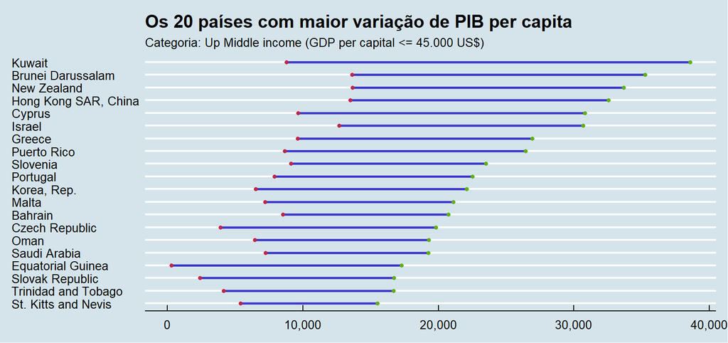

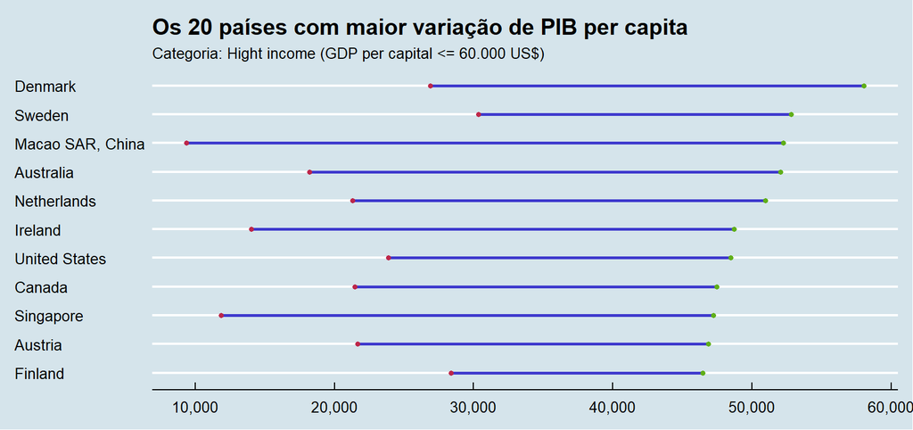

[figure not shown]

Agora vamos ver, para um mesmo país (i.e. Brasil), os diferentes indicadores de PIB que o Banco Mundial possui. Vamos analisar os seguintes indicadores ao longo dos anos:

1. PIB per Capita (PPP)
2. PIB per Capita (LCU - Local currency unit)
3. PIB per Capita (dólar de 2010)
4. PIB per Capita (dólar corrente)

Veja que para trazer mais de um indicador, basta criar uma lista através do comando c(“indicador_1”,“indicador_2”).

```r
df_gdp_pc_3 <- wbstats::wb(indicator = c("NY.GDP.PCAP.PP.CD",
                                         "NY.GDP.PCAP.CN",
                                         "NY.GDP.PCAP.KD",
                                         "NY.GDP.PCAP.CD"),
                           country = "BRA",mrv = 10)
```

Vamos ver uma série temporal destess 4 indicadores.

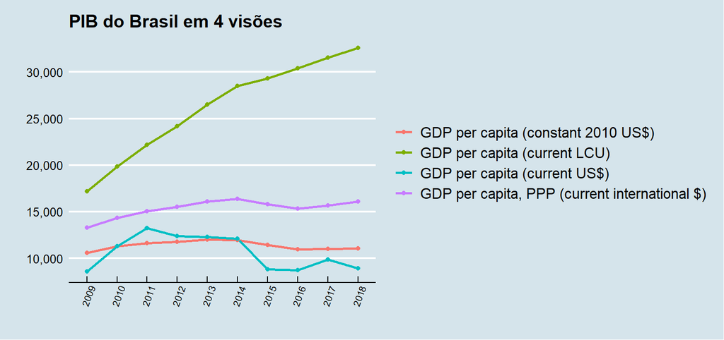

```r
df_gdp_pc_3 %>%
  ggplot(aes(x=date,y=value,group=indicator,color=indicator))+
  geom_line(size=1)+
  geom_point()+
  scale_y_continuous(labels = scales::comma)+
  theme(legend.position = "right",
        legend.title = element_blank(),
        axis.text.x = element_text(size = 8,angle = 70,vjust = .7))+
  labs(
    title = "PIB do Brasil em 4 visões",
    x = "",
    y = ""
  )
```

Continuando com as análises sobre indicadores econômicos dos países da América Latina, vamos ver o débito do governo em proporção ao PIB. Para este indicador, vamos trazer os últimos 20 resultados partindo do mais recente, usando o parâmetro “mrv”.

```r
df_gov_debt <- wbstats::wb(country = "countries_only",
                           indicator = "GC.DOD.TOTL.GD.ZS",
                           mrv = 20) # mrv trazendo os 20 valores mais recentes
```

Após extrair os dados, 870 linhas foram criadas. Vamos ver qual país da América Latina mais aumentou os gastos em proporção ao PIB. Isso pode ocorrer por um aumento efetivo nos gastos ou por uma queda no PIB. Não encontrei informação sobre se a dívida neste indicador é bruta ou líquida, mas vamos seguir assim mesmo.

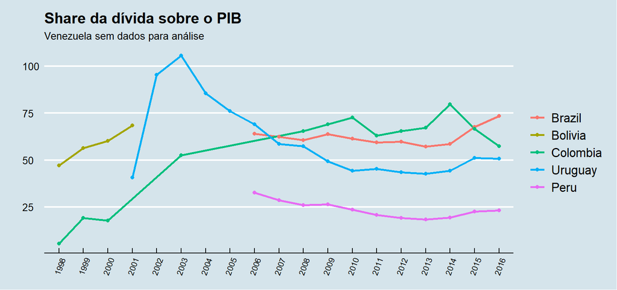

```r
df_gov_debt %>%
  filter(country %in% c("Brazil","Chile","Ecuador","Venezuela, RB",
                        "Colombia","Peru","Argentina","Bolivia",
                        "Uruguay","Paraguay")) %>%
  select(
    country,
    date,
    value
  ) %>%
  mutate(country = factor(country,
                          levels = c( "Brazil",
                                      "Bolivia",
                                      "Colombia",
                                      "Uruguay",
                                      "Peru"))) %>% # reordenando os países
  ggplot(aes(x=date,y=value,group=country,color=country))+
  geom_line(size=1)+
  geom_point()+
  theme(legend.position = "right",
        legend.title = element_blank(),
        axis.text.x = element_text(size = 8,angle = 70,vjust = 0.6),
        axis.title.x = element_blank())+
  labs(
    title = "Share da dívida sobre o PIB",
    subtitle = "Venezuela sem dados para análise",
    x = "",
    y = ""
  )
```

Agora vamos ver qual país da América Latina tem mais share de exportação e importação em relação ao PIB. Este indicador é bem legal para se ver a abertura comercial de um país. Nota-se que Brasil e Argentina são os países mais fechados do continente.

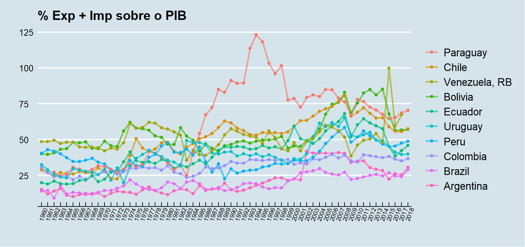

```r
wbstats::wb(indicator = "NE.TRD.GNFS.ZS",country = "countries_only") %>%
  filter(country %in% c("Brazil","Chile","Ecuador","Venezuela, RB",
                        "Colombia","Peru","Argentina","Bolivia",
                        "Uruguay","Paraguay")) %>%
  select(
    country,
    date,
    value
  ) %>%
  mutate(country = fct_reorder(country,value,.desc = T)) %>%
  ggplot(aes(x=date,y=value,group=country,color=country))+
  geom_line(size=1,alpha=.6)+
  geom_point()+
  theme(legend.position = "right",
        legend.title = element_blank(),
        axis.text.x = element_text(size=7,angle = 70,vjust = .8))+ # ajustando o eixo x
  labs(
    title = "% Exp + Imp sobre o PIB",
    x = "",
    y = ""
  )
```

Por último, vamos analisar o índice Gini no continente.

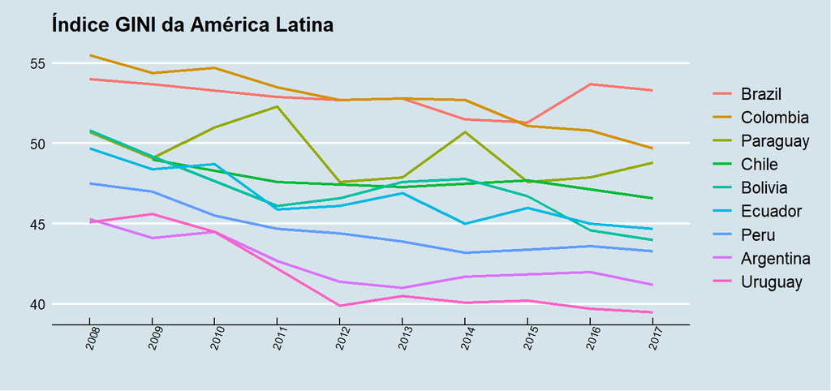

```r
wbstats::wb(indicator = "SI.POV.GINI",country = "countries_only",mrv = 10) %>%
  filter(country %in% c("Brazil","Chile","Ecuador","Venezuela, RB",
                        "Colombia","Peru","Argentina",
                        "Bolivia","Uruguay","Paraguay")) %>%
  select(
    country,
    date,
    value
  ) %>%
  mutate(country = fct_reorder(country,value,.desc = T)) %>%
  ggplot(aes(x=date,y=value,group=country,color=country))+
  geom_line(size=1)+
  theme(legend.position = "right",
        legend.title = element_blank(),
        axis.text.x = element_text(size=8,angle = 70,vjust = .8))+ # ajustando o eixo x
  labs(
    title = "Índice GINI da América Latina",
    x = "",
    y = ""
  )
```

Espero que com os exemplos acima tenha sido possível entender como o pacote funciona. Acredito que esta base de dados pode ser bastante útil em diversos projetos, tanto acadêmicos quanto corporativos. Perceba como foi fácil trabalhar com os dados, sem precisar exportar um csv e depois importat ao R. Em um post futuro irei analisar outros indicadores desta base para buscar novas conclusões.